# Analysis: How successful was LEAFF 2020?

[London East Asia Film Festival (LEAFF)](https://www.leaff.org.uk/)

[Avision Ho](https://github.com/avisionh), Strategy

2020-12-23

# Executive Summary

[figure not shown]

From the post-film survey data, the key findings drawn from those who have attended the festival and filled out a survey are:

**97% rated their LEAFF experience to be “Very good” or “Good”.**

**98% enjoyed LEAFF so much that they would recommend a friend or colleague to attend LEAFF.**

*Introduce you to new types of films (27%), Encourage you to attend similar events (27%) and Increase your appetite for Asian and/or international films (26%)* were the top three reasons why they wanted to attend LEAFF.

**32% said this is their first time coming to the festival, showing that LEAFF was effective in attracting new audience members and retaining previous members.**

# Introduction

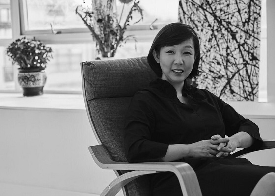

> *The London East Asia Film Festival (LEAFF) is the largest film festival of its kind in London, and represents the culmination of the most inspiring, engaging and inclusive cross-cultural programming. During these turbulent times, it is crucial that we move to understand each other on a humanist and artistic plain, and the exhibition of film — through festivals such as ours — is vital in aiding that communication.*

> *After a hugely popular fourth edition in 2019, we return for our fifth year. We at LEAFF believe that the importance of our festival lies in extending a hand across cultures through the dynamics of story-telling and cinema; and as a global hub, London represents the perfect Western gateway to show films from all over East Asia, appreciating the rich diversity of a region bubbling with creativity and renewal.*

> *In a year where many of us have felt stuck, our festival will allow audiences to be transported to new places and vibrant environments. Therefore, rather than make this edition an online event, our festival will be held in physical theatres across London. We passionately believe this is the only way to move audiences in true and, much needed, cinematic style. It means so much to us that we can continue celebrating Asian culture and platforming important stories through LEAFF this year.*

> *Just like our festival’s emblem, the fish, as a team, we are unblinking and forever moving forward, traversing new lands and stories through film. We welcome you to participate in this journey, and to our festival this year!*

This paper analyses the data collected from the London East Asia Film Festival (LEAFF) 2020. It does so with the intention of providing a summary of how successful the event was, and to provide a benchmark for future editions

# Section 1: Quotes from the Audience

[figure not shown]

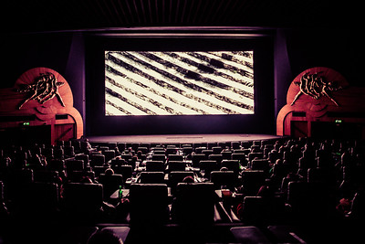

This section presents some of the comments made by audience members who have attended LEAFF 2020.

> *“…really gives the Asian community something to look forward to.”*

> *“Thank you for holding the events at he difficult time!”*

> *“Thank you very much for a great evening.”*

> *“EXCELLENT TOTALLY IMMERSIVE FILM”*

> *“…very pleased it was able to run.”*

> *“This is my favourite festival.”*

> *“Excellent venue and staff!”*

> *“Great festival!”*

# Section 2: Key Performance Metrics

This section presents key analyis of the festival’s performance data.

## Section 2.1: How much did the audience enjoy LEAFF?

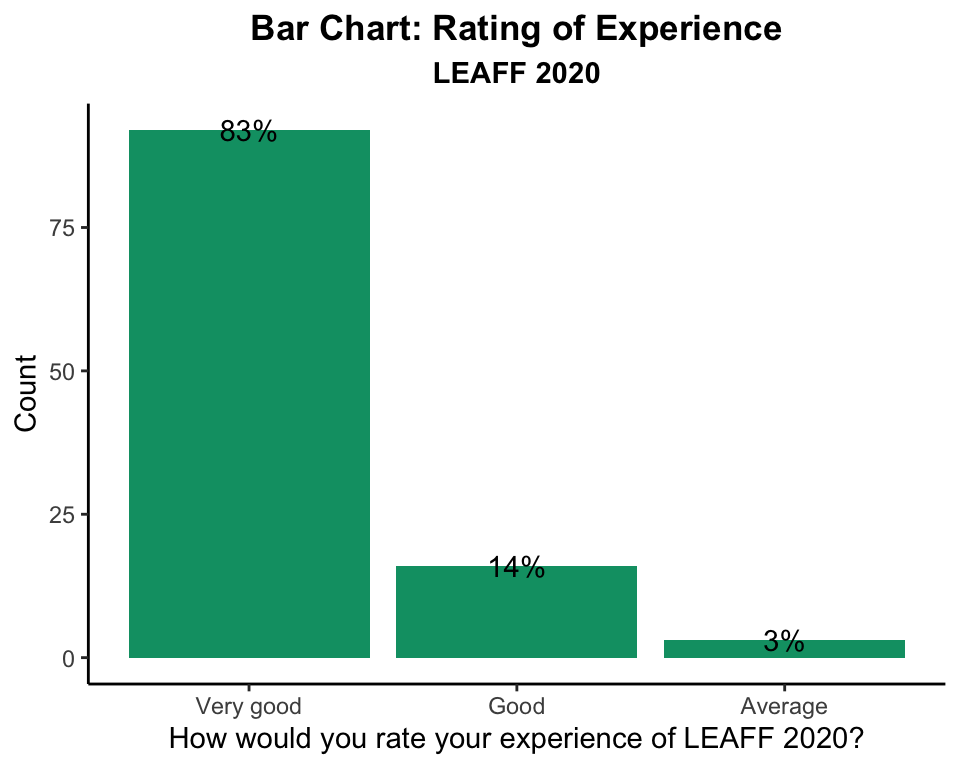

Figure 1

- In **Figure 1**, 97% of attendees rated their LEAFF experience as being **Very good** or **Good**.
- This demonstrates that the majority of attendees enjoyed LEAFF and that the programme and activities which were part of this were successful in capturing the public’s interests and appetite for film and cinema.

## Section 2.2: How likely are the audience to recommend LEAFF to friends and colleagues?

- In the table below, 98% of respondents said they were either **Very likely** or **Likely** to recommend a friend or colleague to attend LEAFF.
- This reinforces the findings made in *Section 2.1* where 97% of respondents said their experience of LEAFF was **Very good** or **Good**.

*Likelihood of audience recommending LEAFF to friends or colleagues*

| Response | Count | Percent |
| --- | --- | --- |
| Neurtal | 3 | 3% |
| Likely | 14 | 13% |
| Very likely | 94 | 85% |

## Section 2.3: Is LEAFF appealing to minority ethnic groups in London?

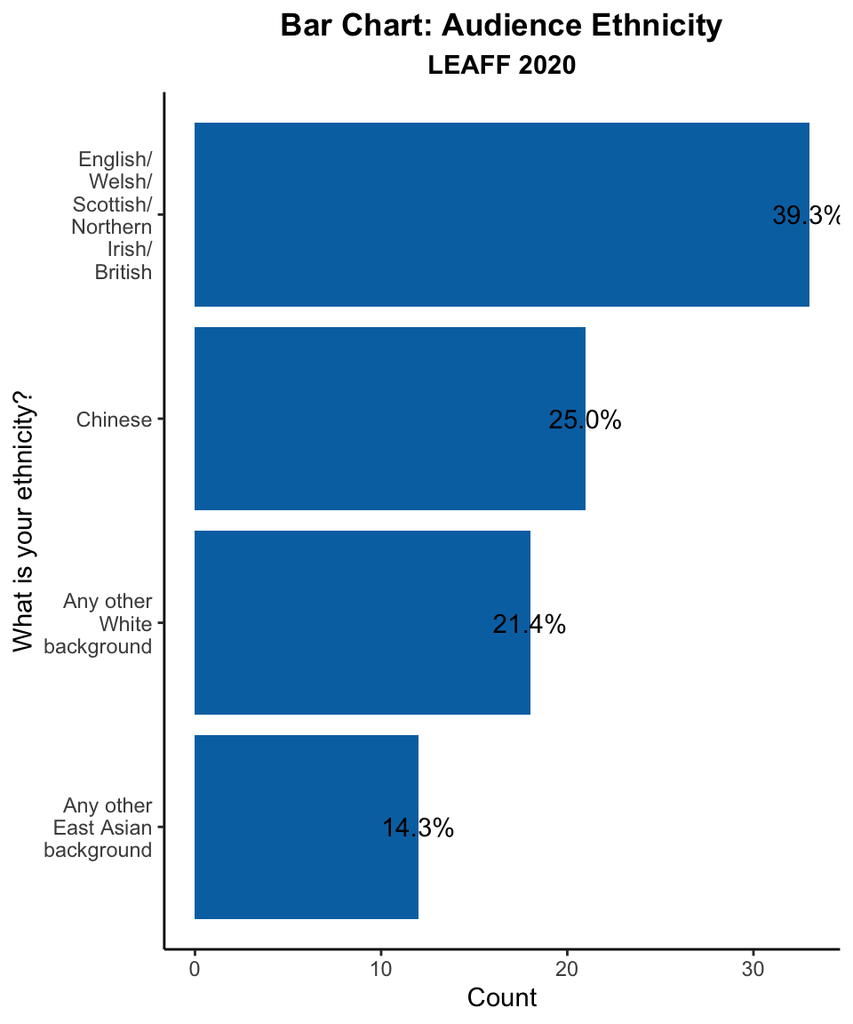

Figure 2: Only showing groups with higher than 10%

## Section 2.4: Why does our audience come to LEAFF?

- Digging further into why 97% of survey respondents enjoyed their LEAFF experience to rate it as **Very good** or **Good**, we see the top three reasons for why they wanted to attend LEAFF were *Introduce you to new types of films (27%), Encourage you to attend similar events (27%) and Increase your appetite for Asian and/or international films (26%)*.
- This demonstrates that LEAFF is more than just a festival but provides immense cultural value in broadening people’s horizons.

## Section 2.5: How many previous and new audiences came to LEAFF?

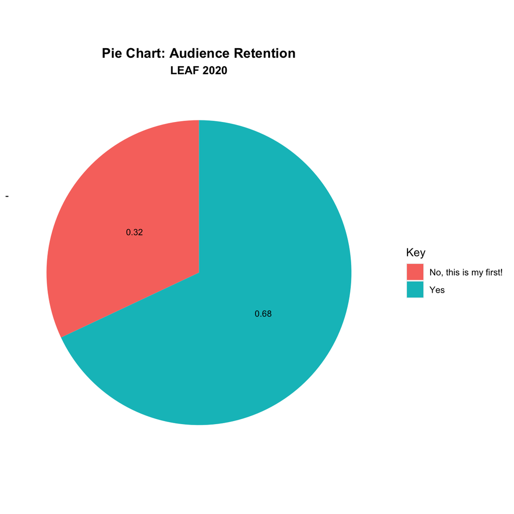

Figure 3

- In **Figure 3**, we have 32% of respondents saying this is their first time coming to the festival.
- Of the remaining 68% of respondents who have returned from previous festivals, we have the following breakdown:
  - Yes - 2015 (8%)
  - Yes - 2016 (11%)
  - Yes - 2017 (18%)
  - Yes - 2018 (26%)
  - Yes - 2019 (36%)
- As a sizeable proportion of attendees have returned to LEAFF from previous years, then this demonstrates that previous LEAFFs were effective in encouraging people to return for this year’s festival.

# Concluding Remarks

[figure not shown]

- From the data analysed in this report, the key findings are:

**Survey respondents enjoyed LEAFF so much that 97% said their experience was *Very good* or *Good*.**

**Survey respondents enjoyed LEAFF so much that 98% of them will recommend a friend or colleague to attend LEAFF.**

**The top three reasons for why survey respondents wanted to attend LEAFF were *Introduce you to new types of films (27%), Encourage you to attend similar events (27%) and Increase your appetite for Asian and/or international films (26%)*.**

**32% of survey respondents said this is their first time coming to the festival, showing that LEAFF was effective in attracting new audience members and retaining previous members.**